# Setup Aging and Demography

`mob_setup`

David Smith

2023-01-31

```r
purl("Demography.Rmd", output = "Demography.R", documentation = 0, quiet=TRUE)
```

## NOTES:

### -

CASES:

- `is.null(ageMesh)`

### `Hpar`

In `exDE` the structure of `Hpar` is the following:

`Hpar`:

- `H` - population density
- `class(Hpar)`
  - `static`
  - `dynamic`
- `Hpar$H`: the population density at setup
  - if `is(Hpar, 'static')` then `class(Hpar$H) <- 'param'`
  - if `is(Hpar, 'dynamic')` then `H` sets the initial conditions
- `Hpar$wf` (*at setup*) used to compute the mixing matrix, $\beta$
- `Hpar$TimeSpent` (*at setup*) used to compute the $\Psi$, the TaR matrix
- `Hpar$Psi`: created by `TiSp2TaR` (currently not implemented, so `Psi = TimeSpent`)
- `Hpar$Hmatrix` defines all demographic state transitions in `dHdt` except for births
- `Hpar$birthF`: `class(Hpar)$birthF` dispatches `F_births`
- `Hpar$birthsXstrata`: `birthsXstrata` is a vector describing which strata get births (*e.g.* the youngest strata)
- `Hpar$birthrate`: all functions define a birth rate.

### configuration

The number of configurable parameters in `Hpar` is not enormous, but configuring setup involves anticipating most of the sensible ways that people *could* choose to stratify populations, and enforcing sound computation internally. The setup problem for ${\cal H}$ is a problem in defining strata in various ways:

- age strata using Galerkin methods to compute age-specific, observable outcomes
- other epidemiologically relevant traits, such as:
  - sex
  - overall level of malaria importation risk (high/low)
  - frailty measures
  - behavioral parameters affecting malaria epidemiology (*e.g.* care seeking, ITN use)
- population birth rates
- time spent / time at risk, which involves location $\times$ age $\times$ time at risk

### setup

The pseudo-code for the setup makes sense if it is done in a certain order:

1. Setup a set of *base strata* based on `TimeSpent`
2. Split the base strata by various traits that do not change dynamically (do later)
3. Split the base strata by other traits that change dynamically (do later)
   - `migrate`
   - `ITNownership`
4. Split the base strata by age, and configure `Hmatrix`
   - using a population `deathrate` passed by the user at setup
   - using an `ageMesh` that defines an aging process
   - modify `wf` by age
5. Configure the `Births` function
   - if `static` then
     - simulate `Hmatrix` to get the `stableAge` distribution
     - set `birthrate`
   - if `dynamic` then use `H` to set initial conditions
6. Setup the `TimeSpent` matrices

### wrappers

`solveCohort` is one wrapper to write (along with `MYZ.Ztrace`) to test/verify the Galerkin methods for age+time. It would set the birth rate to zero, fix initial conditions. This calls for `H.cohort`

## Utils

### AgeWeights

```r
ageF = function(a,shft=0.1){
  aa = (a+shft)/365
  1.7*aa/(4+aa)
}
```

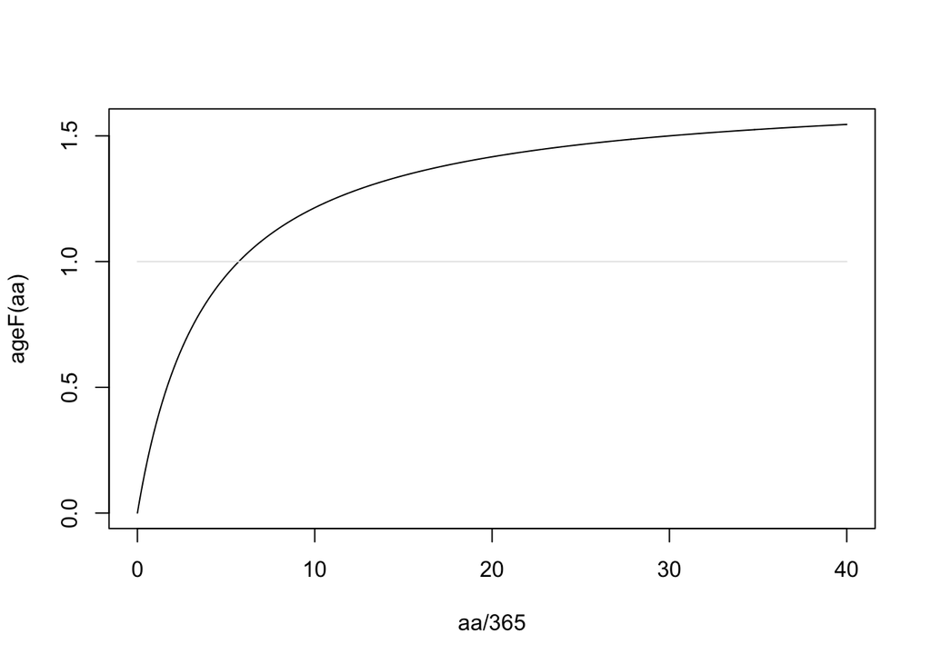

```r
aa = seq(0, 40*365, by = 20)
plot(aa/365, ageF(aa), type = "l")
segments(0,1, 40, 1, col = grey(.9))
```

### Hmatrix

**NOTE** the `ageMesh` is in days. Careful with the strata.

```r
setupHmatrix = function(Hopts){with(Hopts,{

  nBaseStrata = length(H)
  N = 1+length(ageMesh)
  lwAge = c(0, ageMesh)
  upAge = c(ageMesh, 36500)
  midAge = with(Hopts, (lwAge + upAge)/2)
  deathrates = checkIt(deathrates, N)
  searchWtsH = as.vector(outer(ageF(midAge), searchWtsH))
  Hopts$membershipH = as.vector(t(matrix(membershipH, nBaseStrata, N)))
  Hopts$nBaseStrata = nBaseStrata
  Hopts$nAgeStrata = N
  Hopts$nStrata = N*nBaseStrata
  Hopts$lAge = lwAge
  Hopts$uAge = upAge
  Hopts$midAge = midAge
  Hopts$searchWtsH = searchWtsH
  Hopts$Hmatrix = UnevenAgingMatrix(deathrates, ageMesh)
  return(Hopts)
})}
```

```r
UnevenAgingMatrix = function(deathrates, ageMesh){
  N = length(ageMesh)
  checkIt(deathrates, N+1)
  ageUp = c(1/ageMesh,0)
  Aging = diag(-ageUp-deathrates)
  Aging[cbind(1+1:N, 1:N)] = 1/ageMesh
  return(Aging)
}
```

## `H` cases

### make_H_opts

```r
make_H_opts = function(setup_as="null",
                       H=1,
                       membershipH = NULL,
                       nPatches = NULL,
                       searchWtsH = NULL,
                       birthF = "null",
                       deathrates=0,
                       ageweightsF = "0",
                       ageMesh = 0,
                       split_by = list(),
                       Ho=list(),
                       ...){with(Ho,{
  Hopts = list()
  Hopts$setup_as <- setup_as
  class(Hopts) <- setup_as
  Hopts$H <- H
  Hopts$nStrata <- length(H)

  # membershipH: ez setup for demonstrations
  if(!is.null(membershipH) & is.null(nPatches))
    nPatches = max(membershipH)
  if(is.null(membershipH) & is.null(nPatches))
    nPatches = 1
  if(is.null(membershipH))
    membershipH <- (1:length(H) -1) %% nPatches + 1
  Hopts$nPatches <- nPatches
  Hopts$membershipH=membershipH

  # searchwtsH: ez setup for demonstrations
  if(is.null(searchWtsH)) searchWtsH <- rep(1, length(H))
  Hopts$searchWtsH <- checkIt(searchWtsH, length(H), F)

  Hopts$membershipH = membershipH
  Hopts$searchWtsH = searchWtsH
  Hopts$nPatches = nPatches
  Hopts$birthF = birthF
  Hopts$deathrates=deathrates
  Hopts$ageweightsF = ageweightsF
  Hopts$ageMesh = ageMesh
  Hopts$split_by = split_by

  default_H_pars(Hopts, ...)
})}
```

```r
default_H_pars = function(Hopts, ...){
  UseMethod("default_H_pars", Hopts)
}
```

### `null` setup

```r
default_H_pars.null = function(Hopts, ...){with(Hopts,{
  Hopts$baseH = Hopts$H
  Hopts$birthF = "null"
  class(birthF) = "null"
  Hopts$birthF = birthF
  Hopts$birthrate = checkIt(deathrates*H, length(H), F)
  Hmatrix = diag(-deathrates)
  return(Hopts)
})}
```

```r
setup_H.null = function(params, Hopts, TiSp){with(Hopts,{
  nStrata = length(H)
  params$nStrata=nStrata
  params$Hname = "static"
  membershipH = checkIt(membershipH, nStrata, F)
  searchWtsH = checkIt(searchWtsH, nStrata)
  params = make_parameters_demography_null(params, H, membershipH, searchWtsH, TiSp)
  params$Hpar$wf = searchWtsH
  return(params)
})}
```

```r
make_H_opts()
```

```
## $setup_as
## [1] "null"
##
## $H
## [1] 1
##
## $nStrata
## [1] 1
##
## $nPatches
## [1] 1
##
## $membershipH
## [1] 1
##
## $searchWtsH
## [1] 1
##
## $birthF
## [1] "null"
## attr(,"class")
## [1] "null"
##
## $deathrates
## [1] 0
##
## $ageweightsF
## [1] "0"
##
## $ageMesh
## [1] 0
##
## $split_by
## list()
##
## $baseH
## [1] 1
##
## $birthrate
## [1] 0
##
## attr(,"class")
## [1] "null"
```

### static

In the default (easy) case, population denominators are constant over time. In `exDE,` this case is handled by setting the `birthrate` last and using `F_births.constant` See ez F_birth

```r
default_H_pars.static = function(Hopts, ...){
  Hopts$baseH = Hopts$H
  if(max(Hopts$ageMesh)>0){
    Hopts = setupHmatrix(Hopts)
    Hopts$birthsXstrata = c(1, rep(0, length(Hopts$ageMesh)))
    Hopts$birthF = "constant"
  } else {
    Hopts$Hmatrix = diag(-Hopts$deathrates)
    Hopts$birthsXstrata = 1
  }
  Hopts$birthFpars = with(Hopts, setup_birthF(birthF, H, Hmatrix, ...))

  Hopts$H = Hopts$birthFpars$H0
  Hopts$nStrata = length(Hopts$H)
  return(Hopts)
}
```

```r
update_H_pars.static = function(Hpar, H=static, membershipH=static, searchWtsH=static,...){
  if(!is.static(H)) Hpar$H = checkIt(H, length(Hpar$H), F)
  if(!is.static(membershipH)) Hpar$membershipH = checkIt(membershipH, length(Hpar$membershipH), F)
  if(!is.static(searchWtsH)) Hpar$searchWtsH = checkIt(searchWtsH, length(Hpar$searchWtsH), F)
  return(Hpar)
}
```

```r
Hp = make_H_opts("static",  H=c(10, 90, 100, 900), membershipH = c(2,2,3,3), searchWtsH = c(1,3,1,3), ageMesh=365*c(1,2,4,8,16,32), deathrates = c(1/10,1/20,1/40,1/80,1/80,1/50,1/20))
```

```r
Hp
```

[output not shown]

```r
setup_H.static = function(params, Hopts, TiSp){with(Hopts,{
  nStrata = length(H)
  params$nStrata=nStrata
  params$Hname = "static"
  membershipH = checkIt(membershipH, nStrata, F)
  searchWtsH = checkIt(searchWtsH, nStrata)
  params = make_parameters_demography_static(params, H, membershipH, searchWtsH, TiSp, birthFpars, Hmatrix, birthsXstrata)
  params$Hpar$wf = searchWtsH
  params$Hpar$Psi = TiSp
  return(params)
})}
```

```r
pp = list()
pp$nPatches=2
ts = make_TS_opts("0", 3, Hp$membershipH)
setup_H(pp, Hp, ts)
```

[output not shown]

```r
read_Hfile.static = function(prefix, Hname, nStrata){
  Hfilename = paste(prefix, "_Hpar.csv", sep="")
  Hpars = as.data.frame(read.table(Hfilename, sep=","))
  opts = list()
  opts$Hname = Hname
  opts$H = Hpars$H
  opts$membershipH = Hpars$membershipH
  opts$searchWtsH = Hpars$searchWtsH
  return(opts)
}
```

```r
write_Hpar.static = function(model){
  outfile = paste(model$modelName, "_Hpar.csv", sep="")
  Hmatrix = with(model$Hpar, data.frame(H=H, membershipH=membershipH, searchWtsH=searchWtsH))
  write.table(Hmatrix, outfile, sep = ",")
}
```

```r
get_inits_H.static = function(model){
  return(numeric(0))
}
```

### H.dynamic

```r
default_H_pars.dynamic = function(Hopts, ...){
  Hopts$baseH = Hopts$H
  if(max(Hopts$ageMesh)>0){
    Hopts = setupHmatrix(Hopts)
    Hopts$birthsXstrata = c(1, rep(0, length(Hopts$ageMesh)))
  } else {
    with(Hopts,
      if(!exists("deathrates"))
        Hopts$Hmatrix = diag(0, nStrata)
      else
        Hopts$Hmatrix = diag(-Hopts$deathrates)
    )
    Hopts$birthsXstrata = 1
  }
  Hopts$birthFpars = with(Hopts, setup_birthF(birthF, H, Hmatrix, ...))

  Hopts$H = Hopts$birthF$H0
  Hopts$nStrata = length(Hopts$H)
  return(Hopts)
}
```

```r
update_H_pars.dynamic = function(Hpar, H=dynamic, membershipH=dynamic, searchWtsH=dynamic,...){
  if(!is.dynamic(H)) Hpar$H = checkIt(H, length(Hpar$H), F)
  if(!is.dynamic(membershipH)) Hpar$membershipH = checkIt(membershipH, length(Hpar$membershipH), F)
  if(!is.dynamic(searchWtsH)) Hpar$searchWtsH = checkIt(searchWtsH, length(Hpar$searchWtsH), F)
  return(Hpar)
}
```

```r
Hp = make_H_opts("dynamic",  H=c(10, 90, 100, 900), membershipH = c(2,2,3,3), searchWtsH = c(1,3,1,3))
Hp
```

[output not shown]

```r
setup_H.dynamic = function(params, Hopts, TiSp){with(Hopts,{
  nStrata = length(H)
  params$nStrata=nStrata
  params$Hname = "dynamic"
  membershipH = checkIt(membershipH, nStrata, F)
  searchWtsH = checkIt(searchWtsH, nStrata)
  params = make_parameters_demography_dynamic(params, H, membershipH, searchWtsH, TiSp)
  params$Hpar$searchWtsH = searchWtsH
  if(length(Hopts$baseH<Hopts$H)){
    TiSp = TiSp %*% make_calJ(length(Hopts$baseH), Hopts$membershipH)
  } else {
    params$Hpar$Psi = TiSp
  }
  return(params)
})}
```

```r
pp = list()
pp$nPatches=2
ts = make_TS_opts("0", 3, Hp$membershipH)
setup_H(pp, Hp, ts)
```

[output not shown]

```r
read_Hfile.dynamic = function(prefix, Hname, nStrata){
  Hfilename = paste(prefix, "_Hpar.csv", sep="")
  Hpars = as.data.frame(read.table(Hfilename, sep=","))
  opts = list()
  opts$Hname = Hname
  opts$H = Hpars$H
  opts$membershipH = Hpars$membershipH
  opts$searchWtsH = Hpars$searchWtsH
  return(opts)
}
```

```r
write_Hpar.dynamic = function(model){
  outfile = paste(model$modelName, "_Hpar.csv", sep="")
  Hmatrix = with(model$Hpar, data.frame(H=H, membershipH=membershipH, searchWtsH=searchWtsH))
  write.table(Hmatrix, outfile, sep = ",")
}
```

```r
get_inits_H.dynamic = function(model){
  return(numeric(0))
}
```

## solving

### junk

##### -

```r
update_H_pars = function(Hpar, ...){
  UseMethod("update_H_pars", Hpar)
}
```

```r
setup_H = function(params, Hopts, TiSp){
  UseMethod("setup_H", Hopts)
}
```

```r
write_Hpar = function(model){
  UseMethod("write_Hpar", model$Hpar)
}
```

```r
read_Hfile = function(prefix, Hname, nStrata){
  class(Hname) <- Hname
  UseMethod("read_Hfile", Hname)
}
```

##### Demo

```r
make_H_opts()
```

```
## $setup_as
## [1] "null"
##
## $H
## [1] 1
##
## $nStrata
## [1] 1
##
## $nPatches
## [1] 1
##
## $membershipH
## [1] 1
##
## $searchWtsH
## [1] 1
##
## $birthF
## [1] "null"
## attr(,"class")
## [1] "null"
##
## $deathrates
## [1] 0
##
## $ageweightsF
## [1] "0"
##
## $ageMesh
## [1] 0
##
## $split_by
## list()
##
## $baseH
## [1] 1
##
## $birthrate
## [1] 0
##
## attr(,"class")
## [1] "null"
```

```r
make_H_opts("dynamic")
```

[output not shown]

```r
make_H_opts(H=c(10, 20, 30, 40), nPatches=3)
```

```
## $setup_as
## [1] "null"
##
## $H
## [1] 10 20 30 40
##
## $nStrata
## [1] 4
##
## $nPatches
## [1] 3
##
## $membershipH
## [1] 1 2 3 1
##
## $searchWtsH
## [1] 1 1 1 1
##
## $birthF
## [1] "null"
## attr(,"class")
## [1] "null"
##
## $deathrates
## [1] 0
##
## $ageweightsF
## [1] "0"
##
## $ageMesh
## [1] 0
##
## $split_by
## list()
##
## $baseH
## [1] 10 20 30 40
##
## $birthrate
## [1] 0 0 0 0
##
## attr(,"class")
## [1] "null"
```

```r
make_H_opts(H=c(10, 90, 100, 900), membershipH=c(1,1,3,5))
```

```
## $setup_as
## [1] "null"
##
## $H
## [1]  10  90 100 900
##
## $nStrata
## [1] 4
##
## $nPatches
## [1] 5
##
## $membershipH
## [1] 1 1 3 5
##
## $searchWtsH
## [1] 1 1 1 1
##
## $birthF
## [1] "null"
## attr(,"class")
## [1] "null"
##
## $deathrates
## [1] 0
##
## $ageweightsF
## [1] "0"
##
## $ageMesh
## [1] 0
##
## $split_by
## list()
##
## $baseH
## [1]  10  90 100 900
##
## $birthrate
## [1] 0 0 0 0
##
## attr(,"class")
## [1] "null"
```